# Analysis only snellen

group 3

7/19/2019

# Instructions

## Required R packages

- `tidyverse` (or `ggplot2`, `dplyr`, `purrr`, `tibble`)
- `brms`
- `devtools` (for installing `faintr`)
- `rstan`
- `faintr` (install with `devtools`)

Load the required packages and set a seed for the random number generator.

```r
library(tidyverse)
library(rstan)
# set cores to use to the total number of cores (minimally 4)
options(mc.cores = max(parallel::detectCores(), 4))
# save a compiled version of the Stan model file
rstan_options(auto_write = TRUE)
library(brms)
# install faintr with devtools::install_github('michael-franke/bayes_mixed_regression_tutorial/faintr', build_vignettes = TRUE))
library(faintr)
set.seed(123)
```

## Step 1. Read the data and take a glimpse of it.

```r
data_raw <- read_csv("results_71_givemegestalt_group3_group3.csv")
glimpse(data_raw)
```

```
## Observations: 12,078
## Variables: 24
## $ submission_id  <dbl> 566, 566, 566, 566, 566, 566, 566, 566, 566, 56...
## $ QUD            <lgl> NA, NA, NA, NA, NA, NA, NA, NA, NA, NA, NA, NA,...
## $ RT             <dbl> 57807, 13595, 14410, 4927, 4493, 2380, 2907, 66...
## $ age            <dbl> 20, 20, 20, 20, 20, 20, 20, 20, 20, 20, 20, 20,...
## $ comments       <chr> NA, NA, NA, NA, NA, NA, NA, NA, NA, NA, NA, NA,...
## $ endTime        <dbl> 1.562946e+12, 1.562946e+12, 1.562946e+12, 1.562...
## $ experiment_id  <dbl> 71, 71, 71, 71, 71, 71, 71, 71, 71, 71, 71, 71,...
## $ fileID         <dbl> NA, NA, 26, 3, 11, 4, 22, 33, 17, 60, 23, 59, 5...
## $ gender         <chr> "female", "female", "female", "female", "female...
## $ is_expert      <chr> "No", "No", "No", "No", "No", "No", "No", "No",...
## $ min_chars      <dbl> 0, NA, NA, NA, NA, NA, NA, NA, NA, NA, NA, NA, ...
## $ option1        <chr> NA, "Yes", NA, NA, NA, NA, NA, NA, NA, NA, NA, ...
## $ option2        <chr> NA, "No", NA, NA, NA, NA, NA, NA, NA, NA, NA, N...
## $ optionLeft     <chr> NA, NA, "not at all", "not at all", "not at all...
## $ optionRight    <chr> NA, NA, "very much", "very much", "very much", ...
## $ picture        <chr> "images/snellen/snellen.png", NA, "images/stimu...
## $ question       <chr> "Which row is the last one where you can recogn...
## $ response       <chr> "9", "No", "6", "5", "3", "3", "1", "5", "4", "...
## $ snellen_result <dbl> 9, 9, 9, 9, 9, 9, 9, 9, 9, 9, 9, 9, 9, 9, 9, 9,...
## $ startDate      <chr> "Fri Jul 12 2019 17:34:17 GMT+0200 (Mitteleurop...
## $ startTime      <dbl> 1.562946e+12, 1.562946e+12, 1.562946e+12, 1.562...
## $ timeSpent      <dbl> 11.90795, 11.90795, 11.90795, 11.90795, 11.9079...
## $ trial_name     <chr> "test_snellen", "b0_expert", "b1_exp", "b1_exp"...
## $ trial_number   <dbl> 1, 1, 1, 2, 3, 4, 5, 6, 7, 8, 9, 10, 11, 12, 13...
```

Step 2. Select only the columns of interest and filter trials that are not interesting for the calculations. Change data type of the responses to double and submission_id to factor. Delet invalid participants. —

```r
data_selection <- select(data_raw, submission_id, snellen_result, is_expert, age, gender, trial_name, trial_number, fileID, response, RT, timeSpent, comments)
data_filtered <- filter(data_selection, trial_name != "test_snellen", trial_name != "b0_expert")
data_mut <- mutate(data_filtered, response = as.double(response), submission_id = factor(submission_id))
show(data_selection)
```

```
## # A tibble: 12,078 x 12
##    submission_id snellen_result is_expert   age gender trial_name
##            <dbl>          <dbl> <chr>     <dbl> <chr>  <chr>
##  1           566              9 No           20 female test_snel~
##  2           566              9 No           20 female b0_expert
##  3           566              9 No           20 female b1_exp
##  4           566              9 No           20 female b1_exp
##  5           566              9 No           20 female b1_exp
##  6           566              9 No           20 female b1_exp
##  7           566              9 No           20 female b1_exp
##  8           566              9 No           20 female b1_exp
##  9           566              9 No           20 female b1_exp
## 10           566              9 No           20 female b1_exp
## # ... with 12,068 more rows, and 6 more variables: trial_number <dbl>,
## #   fileID <dbl>, response <chr>, RT <dbl>, timeSpent <dbl>,
## #   comments <chr>
```

```r
show(data_filtered)
```

```
## # A tibble: 11,880 x 12
##    submission_id snellen_result is_expert   age gender trial_name
##            <dbl>          <dbl> <chr>     <dbl> <chr>  <chr>
##  1           566              9 No           20 female b1_exp
##  2           566              9 No           20 female b1_exp
##  3           566              9 No           20 female b1_exp
##  4           566              9 No           20 female b1_exp
##  5           566              9 No           20 female b1_exp
##  6           566              9 No           20 female b1_exp
##  7           566              9 No           20 female b1_exp
##  8           566              9 No           20 female b1_exp
##  9           566              9 No           20 female b1_exp
## 10           566              9 No           20 female b1_exp
## # ... with 11,870 more rows, and 6 more variables: trial_number <dbl>,
## #   fileID <dbl>, response <chr>, RT <dbl>, timeSpent <dbl>,
## #   comments <chr>
```

```r
show(data_mut)
```

```
## # A tibble: 11,880 x 12
##    submission_id snellen_result is_expert   age gender trial_name
##    <fct>                  <dbl> <chr>     <dbl> <chr>  <chr>
##  1 566                        9 No           20 female b1_exp
##  2 566                        9 No           20 female b1_exp
##  3 566                        9 No           20 female b1_exp
##  4 566                        9 No           20 female b1_exp
##  5 566                        9 No           20 female b1_exp
##  6 566                        9 No           20 female b1_exp
##  7 566                        9 No           20 female b1_exp
##  8 566                        9 No           20 female b1_exp
##  9 566                        9 No           20 female b1_exp
## 10 566                        9 No           20 female b1_exp
## # ... with 11,870 more rows, and 6 more variables: trial_number <dbl>,
## #   fileID <dbl>, response <dbl>, RT <dbl>, timeSpent <dbl>,
## #   comments <chr>
```

```r
# 3 participants only rated "1" in both blocks, one participant only rated "7", one gave a invalid input for the Snellen test, we exclude them:
data_clean <- filter(data_mut, submission_id != 607, submission_id != 736, submission_id != 475, submission_id != 480, submission_id != 726)
show(data_clean)
```

```
## # A tibble: 11,280 x 12
##    submission_id snellen_result is_expert   age gender trial_name
##    <fct>                  <dbl> <chr>     <dbl> <chr>  <chr>
##  1 566                        9 No           20 female b1_exp
##  2 566                        9 No           20 female b1_exp
##  3 566                        9 No           20 female b1_exp
##  4 566                        9 No           20 female b1_exp
##  5 566                        9 No           20 female b1_exp
##  6 566                        9 No           20 female b1_exp
##  7 566                        9 No           20 female b1_exp
##  8 566                        9 No           20 female b1_exp
##  9 566                        9 No           20 female b1_exp
## 10 566                        9 No           20 female b1_exp
## # ... with 11,270 more rows, and 6 more variables: trial_number <dbl>,
## #   fileID <dbl>, response <dbl>, RT <dbl>, timeSpent <dbl>,
## #   comments <chr>
```

Step 3. Choose only participants who failed the vision test. Split data according to trial (b1: Liking, b2: Detactability). —

```r
# Data for experts
data_sf <- filter(data_clean, snellen_result < 7)
b1_sf <- filter(data_sf, trial_name == "b1_exp")
b2_sf <- filter(data_sf, trial_name == "b2_exp")
show(b1_sf)
```

```
## # A tibble: 180 x 12
##    submission_id snellen_result is_expert   age gender trial_name
##    <fct>                  <dbl> <chr>     <dbl> <chr>  <chr>
##  1 616                        5 No           33 male   b1_exp
##  2 616                        5 No           33 male   b1_exp
##  3 616                        5 No           33 male   b1_exp
##  4 616                        5 No           33 male   b1_exp
##  5 616                        5 No           33 male   b1_exp
##  6 616                        5 No           33 male   b1_exp
##  7 616                        5 No           33 male   b1_exp
##  8 616                        5 No           33 male   b1_exp
##  9 616                        5 No           33 male   b1_exp
## 10 616                        5 No           33 male   b1_exp
## # ... with 170 more rows, and 6 more variables: trial_number <dbl>,
## #   fileID <dbl>, response <dbl>, RT <dbl>, timeSpent <dbl>,
## #   comments <chr>
```

```r
show(b2_sf)
```

```
## # A tibble: 180 x 12
##    submission_id snellen_result is_expert   age gender trial_name
##    <fct>                  <dbl> <chr>     <dbl> <chr>  <chr>
##  1 616                        5 No           33 male   b2_exp
##  2 616                        5 No           33 male   b2_exp
##  3 616                        5 No           33 male   b2_exp
##  4 616                        5 No           33 male   b2_exp
##  5 616                        5 No           33 male   b2_exp
##  6 616                        5 No           33 male   b2_exp
##  7 616                        5 No           33 male   b2_exp
##  8 616                        5 No           33 male   b2_exp
##  9 616                        5 No           33 male   b2_exp
## 10 616                        5 No           33 male   b2_exp
## # ... with 170 more rows, and 6 more variables: trial_number <dbl>,
## #   fileID <dbl>, response <dbl>, RT <dbl>, timeSpent <dbl>,
## #   comments <chr>
```

Step 4. Average data. Generate table with needed non-aggregated data in useful format. —

```r
# Averaged data:
b1_sf_mean <- group_by(b1_sf, fileID) %>% summarise(mean_Like_sf = mean(response))
b2_sf_mean <- group_by(b2_sf, fileID) %>% summarise(mean_Detect_sf = mean(response))
show(b1_sf_mean)
```

```
## # A tibble: 60 x 2
##    fileID mean_Like_sf
##     <dbl>        <dbl>
##  1      1         3.33
##  2      2         2.67
##  3      3         2.33
##  4      4         2.67
##  5      5         2.33
##  6      6         3
##  7      7         3.33
##  8      8         2.67
##  9      9         2.33
## 10     10         2.33
## # ... with 50 more rows
```

```r
show(b2_sf_mean)
```

```
## # A tibble: 60 x 2
##    fileID mean_Detect_sf
##     <dbl>          <dbl>
##  1      1           4.33
##  2      2           4.33
##  3      3           3.67
##  4      4           3.33
##  5      5           3.67
##  6      6           4
##  7      7           5
##  8      8           2.67
##  9      9           4.67
## 10     10           2.67
## # ... with 50 more rows
```

```r
final_sf_mean <- merge(x = b2_sf_mean, y = b1_sf_mean, by = "fileID")
show(final_sf_mean)
```

```
##    fileID mean_Detect_sf mean_Like_sf
## 1       1       4.333333     3.333333
## 2       2       4.333333     2.666667
## 3       3       3.666667     2.333333
## 4       4       3.333333     2.666667
## 5       5       3.666667     2.333333
## 6       6       4.000000     3.000000
## 7       7       5.000000     3.333333
## 8       8       2.666667     2.666667
## 9       9       4.666667     2.333333
## 10     10       2.666667     2.333333
## 11     11       4.000000     2.666667
## 12     12       4.333333     2.333333
## 13     13       3.666667     3.333333
## 14     14       2.666667     2.666667
```

[output cut: 46 more lines]

```r
# Non-average data:
b1_sf_mutated <- mutate(b1_sf, liking_sf = response, RT_liking = RT)
b2_sf_mutated <- mutate(b2_sf, detectability_sf = response, RT_detectability = RT)
b1_sf_selected <- select(b1_sf_mutated, fileID, submission_id, age, snellen_result, timeSpent, liking_sf, RT_liking)
b2_sf_selected <- select(b2_sf_mutated, fileID, submission_id, age, snellen_result, timeSpent, detectability_sf, RT_detectability)
b1_sf_orderd <- b1_sf_selected[order(b1_sf_selected$fileID),]
b2_sf_orderd <- b2_sf_selected[order(b2_sf_selected$fileID),]
merged_sf_data <- b1_sf_orderd
merged_sf_data$detectability_sf <- b2_sf_orderd$detectability_sf
merged_sf_data$RT_detectability <- b2_sf_orderd$RT_detectability
show(b1_sf_selected)
```

```
## # A tibble: 180 x 7
##    fileID submission_id   age snellen_result timeSpent liking_sf RT_liking
##     <dbl> <fct>         <dbl>          <dbl>     <dbl>     <dbl>     <dbl>
##  1      7 616              33              5      12.5         3      5616
##  2     21 616              33              5      12.5         3      3518
##  3     22 616              33              5      12.5         3      2258
##  4     30 616              33              5      12.5         3      1917
##  5     42 616              33              5      12.5         3      5288
##  6     45 616              33              5      12.5         3      3627
##  7     48 616              33              5      12.5         2      2051
##  8     34 616              33              5      12.5         2      2907
##  9      1 616              33              5      12.5         2      3477
## 10     55 616              33              5      12.5         2      2395
## # ... with 170 more rows
```

```r
show(b2_sf_selected)
```

```
## # A tibble: 180 x 7
##    fileID submission_id   age snellen_result timeSpent detectability_sf
##     <dbl> <fct>         <dbl>          <dbl>     <dbl>            <dbl>
##  1      1 616              33              5      12.5                5
##  2     15 616              33              5      12.5                5
##  3     56 616              33              5      12.5                3
##  4     37 616              33              5      12.5                6
##  5     36 616              33              5      12.5                6
##  6     18 616              33              5      12.5                5
##  7     25 616              33              5      12.5                5
##  8     26 616              33              5      12.5                6
##  9     60 616              33              5      12.5                2
## 10     31 616              33              5      12.5                2
## # ... with 170 more rows, and 1 more variable: RT_detectability <dbl>
```

```r
show(b1_sf_orderd)
```

```
## # A tibble: 180 x 7
##    fileID submission_id   age snellen_result timeSpent liking_sf RT_liking
##     <dbl> <fct>         <dbl>          <dbl>     <dbl>     <dbl>     <dbl>
##  1      1 616              33              5     12.5          2      3477
##  2      1 582              21              6      5.98         4      1848
##  3      1 479              26              4      7.92         4      3064
##  4      2 616              33              5     12.5          2      5169
##  5      2 582              21              6      5.98         1      1981
##  6      2 479              26              4      7.92         5      2624
##  7      3 616              33              5     12.5          2      2087
##  8      3 582              21              6      5.98         3      2183
##  9      3 479              26              4      7.92         2      2312
## 10      4 616              33              5     12.5          2       976
## # ... with 170 more rows
```

```r
show(b2_sf_orderd)
```

```
## # A tibble: 180 x 7
##    fileID submission_id   age snellen_result timeSpent detectability_sf
##     <dbl> <fct>         <dbl>          <dbl>     <dbl>            <dbl>
##  1      1 616              33              5     12.5                 5
##  2      1 582              21              6      5.98                5
##  3      1 479              26              4      7.92                3
##  4      2 616              33              5     12.5                 4
##  5      2 582              21              6      5.98                6
##  6      2 479              26              4      7.92                3
##  7      3 616              33              5     12.5                 1
##  8      3 582              21              6      5.98                7
##  9      3 479              26              4      7.92                3
## 10      4 616              33              5     12.5                 2
## # ... with 170 more rows, and 1 more variable: RT_detectability <dbl>
```

```r
show(merged_sf_data)
```

```
## # A tibble: 180 x 9
##    fileID submission_id   age snellen_result timeSpent liking_sf RT_liking
##     <dbl> <fct>         <dbl>          <dbl>     <dbl>     <dbl>     <dbl>
##  1      1 616              33              5     12.5          2      3477
##  2      1 582              21              6      5.98         4      1848
##  3      1 479              26              4      7.92         4      3064
##  4      2 616              33              5     12.5          2      5169
##  5      2 582              21              6      5.98         1      1981
##  6      2 479              26              4      7.92         5      2624
##  7      3 616              33              5     12.5          2      2087
##  8      3 582              21              6      5.98         3      2183
##  9      3 479              26              4      7.92         2      2312
## 10      4 616              33              5     12.5          2       976
## # ... with 170 more rows, and 2 more variables: detectability_sf <dbl>,
## #   RT_detectability <dbl>
```

```r
final_sf <- as_tibble(merged_sf_data)
show(final_sf)
```

```
## # A tibble: 180 x 9
##    fileID submission_id   age snellen_result timeSpent liking_sf RT_liking
##     <dbl> <fct>         <dbl>          <dbl>     <dbl>     <dbl>     <dbl>
##  1      1 616              33              5     12.5          2      3477
##  2      1 582              21              6      5.98         4      1848
##  3      1 479              26              4      7.92         4      3064
##  4      2 616              33              5     12.5          2      5169
##  5      2 582              21              6      5.98         1      1981
##  6      2 479              26              4      7.92         5      2624
##  7      3 616              33              5     12.5          2      2087
##  8      3 582              21              6      5.98         3      2183
##  9      3 479              26              4      7.92         2      2312
## 10      4 616              33              5     12.5          2       976
## # ... with 170 more rows, and 2 more variables: detectability_sf <dbl>,
## #   RT_detectability <dbl>
```

## Step 5.Test assumptions for linear regression.

Normality:

```r
# Non-averaged data:
ks.test(b1_sf$response, pnorm)
```

```
##
##  One-sample Kolmogorov-Smirnov test
##
## data:  b1_sf$response
## D = 0.88281, p-value < 2.2e-16
## alternative hypothesis: two-sided
```

```r
ks.test(b2_sf$response, pnorm)
```

```
##
##  One-sample Kolmogorov-Smirnov test
##
## data:  b2_sf$response
## D = 0.93836, p-value < 2.2e-16
## alternative hypothesis: two-sided
```

```r
# Averaged data:
ks.test(b1_sf_mean$mean_Like_sf, pnorm)
```

```
##
##  One-sample Kolmogorov-Smirnov test
##
## data:  b1_sf_mean$mean_Like_sf
## D = 0.97725, p-value < 2.2e-16
## alternative hypothesis: two-sided
```

```r
ks.test(b2_sf_mean$mean_Detect_sf, pnorm)
```

```
##
##  One-sample Kolmogorov-Smirnov test
##
## data:  b2_sf_mean$mean_Detect_sf
## D = 0.97725, p-value < 2.2e-16
## alternative hypothesis: two-sided
```

Result: According to the Kolmogorov-Smirnov test the variables are not normal distributed. Hence, the normality assumption is not fullfiled. We will test the residual distribution in the next step to make sure that we can still use a linear regression.

Further assumptions:

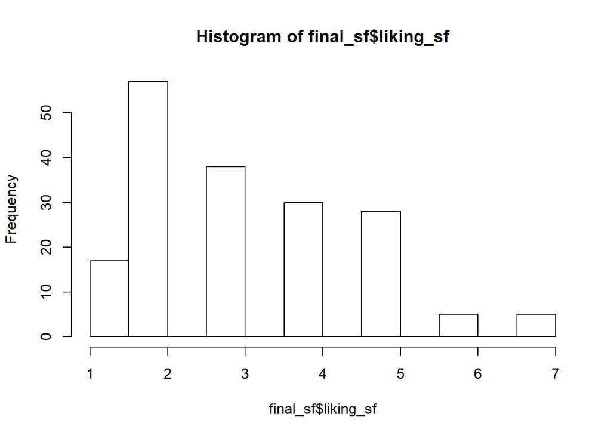

```r
# Non-averaged data:
hist(final_sf$liking_sf)
```

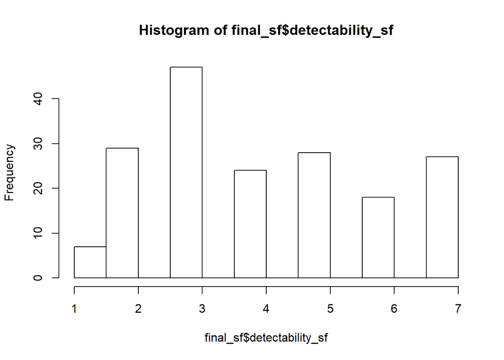

```r
hist(final_sf$detectability_sf)
```

```r
par(mfrow=c(2,2))
typeof(final_sf)
```

```
## [1] "list"
```

```r
mod_sf <- lm(final_sf$liking_sf ~ final_sf$detectability_sf, data=final_sf) #linear regression model
gvlma::gvlma(mod_sf) # further tests for assumtions
```

```
##
## Call:
## lm(formula = final_sf$liking_sf ~ final_sf$detectability_sf,
##     data = final_sf)
##
## Coefficients:
##               (Intercept)  final_sf$detectability_sf
##                    3.2258                    -0.0144
##
##
## ASSESSMENT OF THE LINEAR MODEL ASSUMPTIONS
## USING THE GLOBAL TEST ON 4 DEGREES-OF-FREEDOM:
## Level of Significance =  0.05
##
## Call:
##  gvlma::gvlma(x = mod_sf)
##
##                       Value  p-value                   Decision
## Global Stat        10.65785 0.030691 Assumptions NOT satisfied!
## Skewness            9.83682 0.001711 Assumptions NOT satisfied!
## Kurtosis            0.79602 0.372285    Assumptions acceptable.
## Link Function       0.01264 0.910488    Assumptions acceptable.
## Heteroscedasticity  0.01237 0.911449    Assumptions acceptable.
```

```r
summary(mod_sf) # Show summary to check p-value
```

```
##
## Call:
## lm(formula = final_sf$liking_sf ~ final_sf$detectability_sf,
##     data = final_sf)
##
## Residuals:
##     Min      1Q  Median      3Q     Max
## -2.1826 -1.1826 -0.1682  0.8462  3.8606
##
## Coefficients:
##                           Estimate Std. Error t value Pr(>|t|)
## (Intercept)                3.22580    0.27693  11.649   <2e-16 ***
## final_sf$detectability_sf -0.01440    0.06191  -0.233    0.816
## ---
## Signif. codes:  0 '***' 0.001 '**' 0.01 '*' 0.05 '.' 0.1 ' ' 1
##
## Residual standard error: 1.474 on 178 degrees of freedom
## Multiple R-squared:  0.0003039,  Adjusted R-squared:  -0.005312
## F-statistic: 0.05412 on 1 and 178 DF,  p-value: 0.8163
```

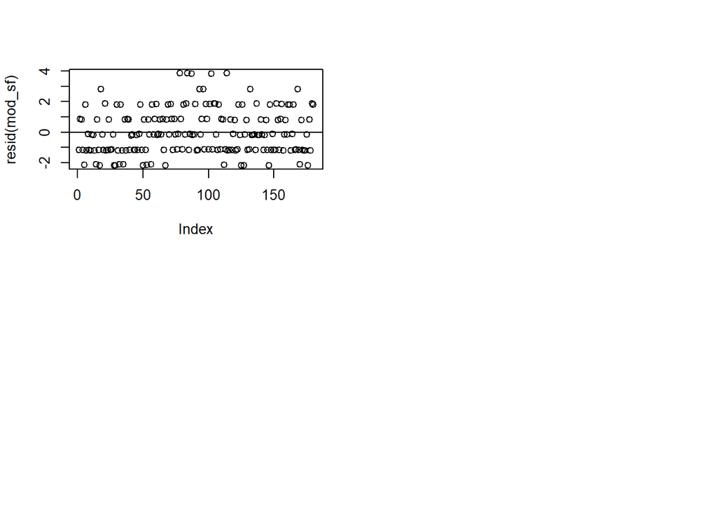

```r
plot(resid(mod_sf)) # Plot residuals to check if normality assumption is necessary
abline(a=0,b=0)
```

Result: Some of the assumptions are not satisfied. Linear regression is not optimal

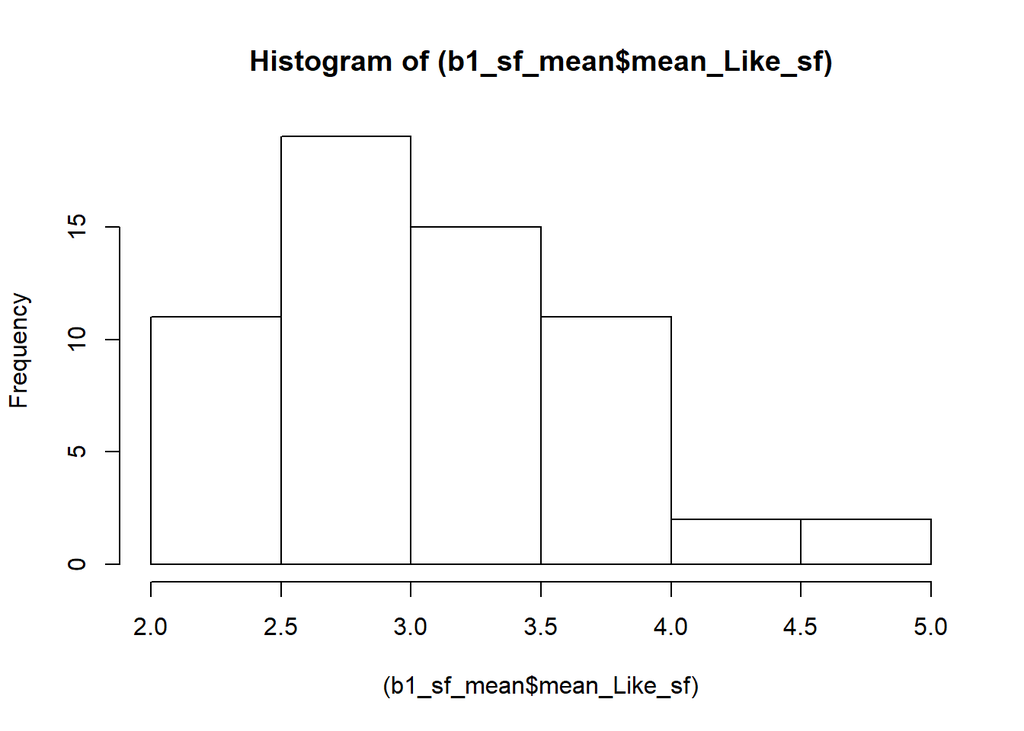

```r
# Averaged data:
hist((b1_sf_mean$mean_Like_sf))
```

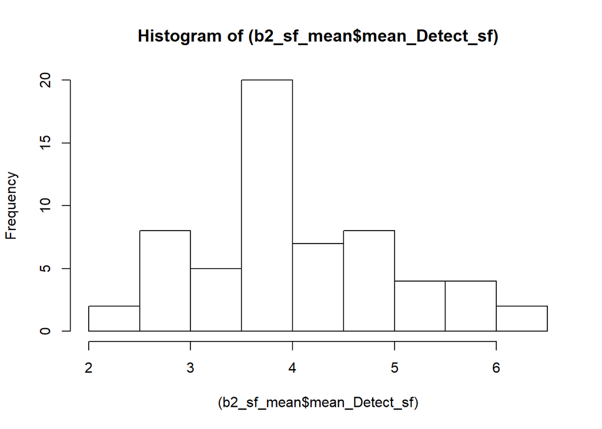

```r
hist((b2_sf_mean$mean_Detect_sf))
```

```r
par(mfrow=c(2,2))
typeof((b1_sf_mean))
```

```
## [1] "list"
```

```r
mod_mean_sf <- lm((b1_sf_mean$mean_Like_sf) ~ (b2_sf_mean$mean_Detect_sf), data=final_sf_mean) # linear regression model
gvlma::gvlma(mod_mean_sf) # further tests for assumtions
```

```
##
## Call:
## lm(formula = (b1_sf_mean$mean_Like_sf) ~ (b2_sf_mean$mean_Detect_sf),
##     data = final_sf_mean)
##
## Coefficients:
##               (Intercept)  b2_sf_mean$mean_Detect_sf
##                    1.7026                     0.3566
##
##
## ASSESSMENT OF THE LINEAR MODEL ASSUMPTIONS
## USING THE GLOBAL TEST ON 4 DEGREES-OF-FREEDOM:
## Level of Significance =  0.05
##
## Call:
##  gvlma::gvlma(x = mod_mean_sf)
##
##                      Value p-value                Decision
## Global Stat        2.72106  0.6055 Assumptions acceptable.
## Skewness           1.18867  0.2756 Assumptions acceptable.
## Kurtosis           0.05091  0.8215 Assumptions acceptable.
## Link Function      1.08933  0.2966 Assumptions acceptable.
## Heteroscedasticity 0.39215  0.5312 Assumptions acceptable.
```

```r
summary(mod_mean_sf) # Show summary to check p-value
```

```
##
## Call:
## lm(formula = (b1_sf_mean$mean_Like_sf) ~ (b2_sf_mean$mean_Detect_sf),
##     data = final_sf_mean)
##
## Residuals:
##     Min      1Q  Median      3Q     Max
## -1.0334 -0.3668  0.0260  0.3232  1.5609
##
## Coefficients:
##                           Estimate Std. Error t value Pr(>|t|)
## (Intercept)                1.70259    0.30518   5.579 6.66e-07 ***
## b2_sf_mean$mean_Detect_sf  0.35661    0.07228   4.933 7.15e-06 ***
## ---
## Signif. codes:  0 '***' 0.001 '**' 0.01 '*' 0.05 '.' 0.1 ' ' 1
##
## Residual standard error: 0.551 on 58 degrees of freedom
## Multiple R-squared:  0.2956, Adjusted R-squared:  0.2834
## F-statistic: 24.34 on 1 and 58 DF,  p-value: 7.147e-06
```

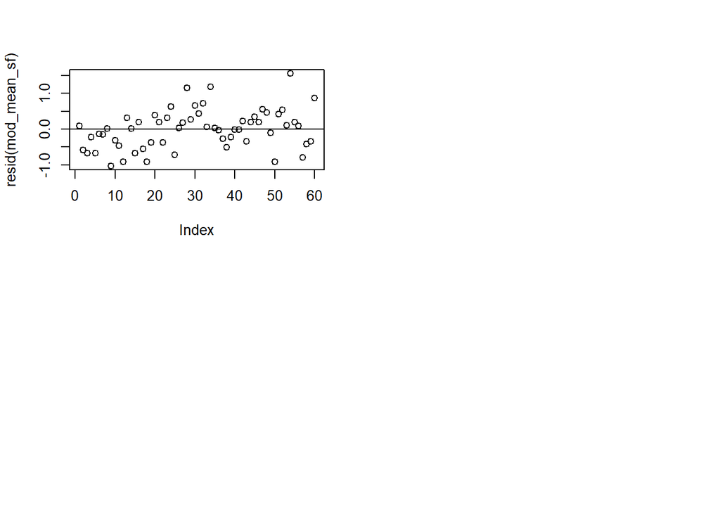

```r
plot(resid(mod_mean_sf)) # Plot residuals to check if normality assumption is necessary
abline(a=0,b=0)
```

Result: The assumptions for linear regression are satisfied. The distribution of the residuals shows asymmetry along the zero line, but not enough to violate the normality assumption. The p-value shows us that our model is significant. The R-squared value is lower than in the original paper.

## Step 6. Make a plot of the averaged data.

```r
cor((b2_sf_mean$mean_Detect_sf), (b1_sf_mean$mean_Like_sf))
```

```
## [1] 0.5436804
```

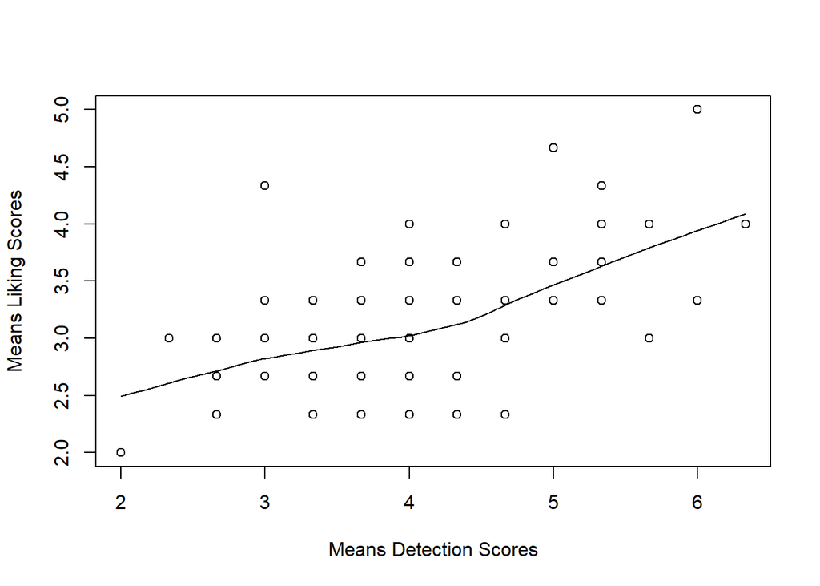

```r
scatter.smooth(y= (b1_sf_mean$mean_Like_sf), x= (b2_sf_mean$mean_Detect_sf), xlab = "Means Detection Scores", ylab = "Means Liking Scores")
```

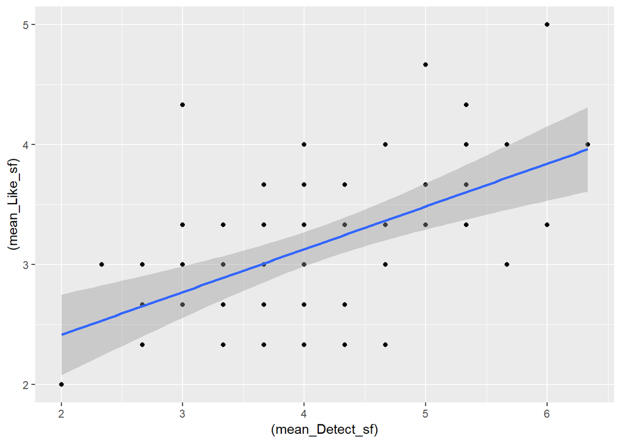

```r
ggplot(final_sf_mean, aes(x = (mean_Detect_sf), y = (mean_Like_sf))) + geom_point() + geom_smooth(method = "lm")
```

Results: The correlation between the two variables Liking and Detectability is positive, but lower than in the original experiment. The lower R-squared value can be explained by outliers.

## Step 7. Run bayesian fixed-effects models

Averaged Data:

```r
brm_sf_gaussian <- brm(formula=mean_Like_sf ~ mean_Detect_sf, data=final_sf_mean, family = "gaussian")
summary(brm_sf_gaussian)
```

```
##  Family: gaussian
##   Links: mu = identity; sigma = identity
## Formula: mean_Like_sf ~ mean_Detect_sf
##    Data: final_sf_mean (Number of observations: 60)
## Samples: 4 chains, each with iter = 2000; warmup = 1000; thin = 1;
##          total post-warmup samples = 4000
##
## Population-Level Effects:
##                Estimate Est.Error l-95% CI u-95% CI Eff.Sample Rhat
## Intercept          1.69      0.31     1.09     2.32       3355 1.00
## mean_Detect_sf     0.36      0.07     0.21     0.50       3404 1.00
##
## Family Specific Parameters:
##       Estimate Est.Error l-95% CI u-95% CI Eff.Sample Rhat
## sigma     0.56      0.05     0.47     0.68       3795 1.00
##
## Samples were drawn using sampling(NUTS). For each parameter, Eff.Sample
## is a crude measure of effective sample size, and Rhat is the potential
## scale reduction factor on split chains (at convergence, Rhat = 1).
```

Result: Positive correlation.

Non-Averaged data: Cumulative family:

```r
final_sf_mutated <- mutate(final_sf, liking_sf = as.integer(liking_sf), detectability_sf = as.integer(detectability_sf))
brm_sf_cumulative <- brm(formula=liking_sf ~ mo(detectability_sf), data=final_sf_mutated, family = "cumulative")
summary(brm_sf_cumulative)
```

```
##  Family: cumulative
##   Links: mu = logit; disc = identity
## Formula: liking_sf ~ mo(detectability_sf)
##    Data: final_sf_mutated (Number of observations: 180)
## Samples: 4 chains, each with iter = 2000; warmup = 1000; thin = 1;
##          total post-warmup samples = 4000
##
## Population-Level Effects:
##                    Estimate Est.Error l-95% CI u-95% CI Eff.Sample Rhat
## Intercept[1]          -2.39      0.36    -3.10    -1.70       2654 1.00
## Intercept[2]          -0.46      0.29    -1.04     0.12       3330 1.00
## Intercept[3]           0.41      0.30    -0.18     0.99       3520 1.00
## Intercept[4]           1.25      0.31     0.64     1.87       3650 1.00
## Intercept[5]           2.82      0.41     2.05     3.68       4890 1.00
## Intercept[6]           3.69      0.53     2.74     4.83       5896 1.00
## modetectability_sf    -0.03      0.08    -0.18     0.12       3387 1.00
##
## Simplex Parameters:
##                        Estimate Est.Error l-95% CI u-95% CI Eff.Sample
## modetectability_sf1[1]     0.18      0.15     0.01     0.56       6194
## modetectability_sf1[2]     0.17      0.14     0.01     0.52       6896
## modetectability_sf1[3]     0.16      0.13     0.01     0.50       6741
## modetectability_sf1[4]     0.16      0.14     0.00     0.51       5623
## modetectability_sf1[5]     0.16      0.14     0.01     0.52       5022
## modetectability_sf1[6]     0.17      0.14     0.01     0.54       5154
##                        Rhat
## modetectability_sf1[1] 1.00
## modetectability_sf1[2] 1.00
## modetectability_sf1[3] 1.00
## modetectability_sf1[4] 1.00
## modetectability_sf1[5] 1.00
## modetectability_sf1[6] 1.00
##
## Samples were drawn using sampling(NUTS). For each parameter, Eff.Sample
## is a crude measure of effective sample size, and Rhat is the potential
## scale reduction factor on split chains (at convergence, Rhat = 1).
```

Cumulative family for mixed/random effects:

```r
brm_sf_mixed <- brm(formula=liking_sf ~ mo(detectability_sf) + (1|submission_id), data=final_sf_mutated, family = "cumulative")
summary(brm_sf_mixed)
```

```
##  Family: cumulative
##   Links: mu = logit; disc = identity
## Formula: liking_sf ~ mo(detectability_sf) + (1 | submission_id)
##    Data: final_sf_mutated (Number of observations: 180)
## Samples: 4 chains, each with iter = 2000; warmup = 1000; thin = 1;
##          total post-warmup samples = 4000
##
## Group-Level Effects:
## ~submission_id (Number of levels: 3)
##               Estimate Est.Error l-95% CI u-95% CI Eff.Sample Rhat
## sd(Intercept)     3.38      2.09     1.09     9.28       1251 1.00
##
## Population-Level Effects:
##                    Estimate Est.Error l-95% CI u-95% CI Eff.Sample Rhat
## Intercept[1]          -2.95      1.79    -6.96     0.46       1246 1.00
## Intercept[2]          -0.64      1.77    -4.59     2.78       1268 1.00
## Intercept[3]           0.75      1.77    -3.16     4.17       1268 1.00
## Intercept[4]           2.00      1.77    -1.92     5.45       1281 1.00
## Intercept[5]           3.86      1.80    -0.06     7.38       1290 1.00
## Intercept[6]           4.80      1.83     0.88     8.34       1333 1.00
## modetectability_sf     0.19      0.09     0.01     0.39       3776 1.00
##
## Simplex Parameters:
##                        Estimate Est.Error l-95% CI u-95% CI Eff.Sample
## modetectability_sf1[1]     0.16      0.13     0.01     0.47       4627
## modetectability_sf1[2]     0.10      0.10     0.00     0.36       4663
## modetectability_sf1[3]     0.15      0.13     0.00     0.47       4982
## modetectability_sf1[4]     0.22      0.16     0.01     0.60       4000
## modetectability_sf1[5]     0.22      0.16     0.01     0.58       3859
## modetectability_sf1[6]     0.15      0.12     0.01     0.45       4254
##                        Rhat
## modetectability_sf1[1] 1.00
## modetectability_sf1[2] 1.00
## modetectability_sf1[3] 1.00
## modetectability_sf1[4] 1.00
## modetectability_sf1[5] 1.00
## modetectability_sf1[6] 1.00
##
## Samples were drawn using sampling(NUTS). For each parameter, Eff.Sample
## is a crude measure of effective sample size, and Rhat is the potential
## scale reduction factor on split chains (at convergence, Rhat = 1).
```

```r
brm_sf_mixed2 <- brm(formula=liking_sf ~ mo(detectability_sf) + (1|submission_id) + (1|fileID), data=final_sf_mutated, family = "cumulative")
summary(brm_sf_mixed2)
```

```
##  Family: cumulative
##   Links: mu = logit; disc = identity
## Formula: liking_sf ~ mo(detectability_sf) + (1 | submission_id) + (1 | fileID)
##    Data: final_sf_mutated (Number of observations: 180)
## Samples: 4 chains, each with iter = 2000; warmup = 1000; thin = 1;
##          total post-warmup samples = 4000
##
## Group-Level Effects:
## ~fileID (Number of levels: 60)
##               Estimate Est.Error l-95% CI u-95% CI Eff.Sample Rhat
## sd(Intercept)     0.27      0.19     0.01     0.71       1318 1.00
##
## ~submission_id (Number of levels: 3)
##               Estimate Est.Error l-95% CI u-95% CI Eff.Sample Rhat
## sd(Intercept)     3.31      2.03     1.10     8.94       1658 1.00
##
## Population-Level Effects:
##                    Estimate Est.Error l-95% CI u-95% CI Eff.Sample Rhat
## Intercept[1]          -2.93      1.68    -6.67     0.41       1604 1.00
## Intercept[2]          -0.59      1.67    -4.24     2.68       1594 1.00
## Intercept[3]           0.81      1.68    -2.85     4.11       1609 1.00
## Intercept[4]           2.07      1.68    -1.54     5.44       1604 1.00
## Intercept[5]           3.96      1.71     0.23     7.28       1680 1.00
## Intercept[6]           4.91      1.75     1.21     8.28       1699 1.00
## modetectability_sf     0.18      0.10    -0.01     0.37       4276 1.00
##
## Simplex Parameters:
##                        Estimate Est.Error l-95% CI u-95% CI Eff.Sample
## modetectability_sf1[1]     0.15      0.13     0.00     0.47       6153
## modetectability_sf1[2]     0.11      0.10     0.00     0.37       5506
## modetectability_sf1[3]     0.15      0.13     0.00     0.46       6468
## modetectability_sf1[4]     0.22      0.16     0.01     0.58       5294
## modetectability_sf1[5]     0.21      0.15     0.01     0.59       4760
## modetectability_sf1[6]     0.16      0.13     0.01     0.47       4543
##                        Rhat
## modetectability_sf1[1] 1.00
## modetectability_sf1[2] 1.00
## modetectability_sf1[3] 1.00
## modetectability_sf1[4] 1.00
## modetectability_sf1[5] 1.00
## modetectability_sf1[6] 1.00
##
## Samples were drawn using sampling(NUTS). For each parameter, Eff.Sample
## is a crude measure of effective sample size, and Rhat is the potential
## scale reduction factor on split chains (at convergence, Rhat = 1).
```

## Step 8. Compare different bmr models.

```r
loo(brm_sf_cumulative, brm_sf_mixed)
```

```
## Output of model 'brm_sf_cumulative':
##
## Computed from 4000 by 180 log-likelihood matrix
##
##          Estimate   SE
## elpd_loo   -313.6  8.5
## p_loo         7.2  0.6
## looic       627.2 17.0
## ------
## Monte Carlo SE of elpd_loo is 0.0.
##
## All Pareto k estimates are good (k < 0.5).
## See help('pareto-k-diagnostic') for details.
##
## Output of model 'brm_sf_mixed':
##
## Computed from 4000 by 180 log-likelihood matrix
##
##          Estimate   SE
## elpd_loo   -270.4  9.6
## p_loo        10.3  0.8
## looic       540.8 19.2
## ------
## Monte Carlo SE of elpd_loo is 0.1.
##
## All Pareto k estimates are good (k < 0.5).
## See help('pareto-k-diagnostic') for details.
##
## Model comparisons:
##                   elpd_diff se_diff
## brm_sf_mixed        0.0       0.0
## brm_sf_cumulative -43.2       7.7
```

```r
loo(brm_sf_cumulative, brm_sf_mixed2)
```

```
## Output of model 'brm_sf_cumulative':
##
## Computed from 4000 by 180 log-likelihood matrix
##
##          Estimate   SE
## elpd_loo   -313.6  8.5
## p_loo         7.2  0.6
## looic       627.2 17.0
## ------
## Monte Carlo SE of elpd_loo is 0.0.
##
## All Pareto k estimates are good (k < 0.5).
## See help('pareto-k-diagnostic') for details.
##
## Output of model 'brm_sf_mixed2':
##
## Computed from 4000 by 180 log-likelihood matrix
##
##          Estimate   SE
## elpd_loo   -271.7  9.6
## p_loo        15.5  1.1
## looic       543.4 19.2
## ------
## Monte Carlo SE of elpd_loo is 0.1.
##
## All Pareto k estimates are good (k < 0.5).
## See help('pareto-k-diagnostic') for details.
##
## Model comparisons:
##                   elpd_diff se_diff
## brm_sf_mixed2       0.0       0.0
## brm_sf_cumulative -41.9       7.6
```

```r
loo(brm_sf_mixed, brm_sf_mixed2)
```

```
## Output of model 'brm_sf_mixed':
##
## Computed from 4000 by 180 log-likelihood matrix
##
##          Estimate   SE
## elpd_loo   -270.4  9.6
## p_loo        10.3  0.8
## looic       540.8 19.2
## ------
## Monte Carlo SE of elpd_loo is 0.1.
##
## All Pareto k estimates are good (k < 0.5).
## See help('pareto-k-diagnostic') for details.
##
## Output of model 'brm_sf_mixed2':
##
## Computed from 4000 by 180 log-likelihood matrix
##
##          Estimate   SE
## elpd_loo   -271.7  9.6
## p_loo        15.5  1.1
## looic       543.4 19.2
## ------
## Monte Carlo SE of elpd_loo is 0.1.
##
## All Pareto k estimates are good (k < 0.5).
## See help('pareto-k-diagnostic') for details.
##
## Model comparisons:
##               elpd_diff se_diff
## brm_sf_mixed   0.0       0.0
## brm_sf_mixed2 -1.3       0.5
```

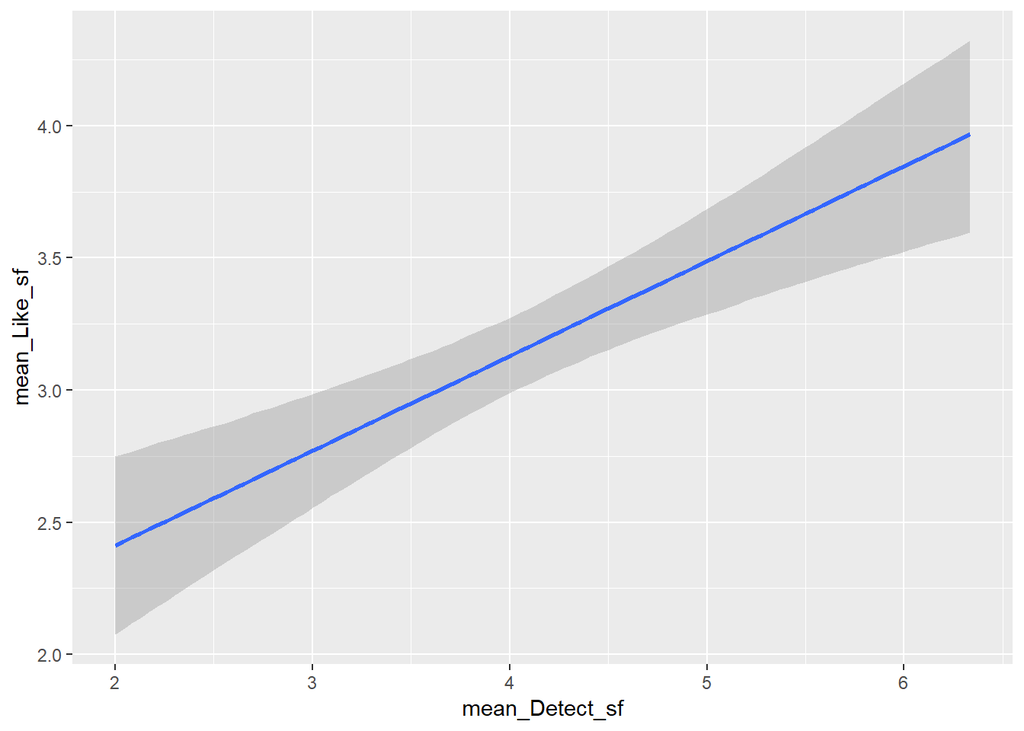

```r
marginal_effects(brm_sf_gaussian)
```

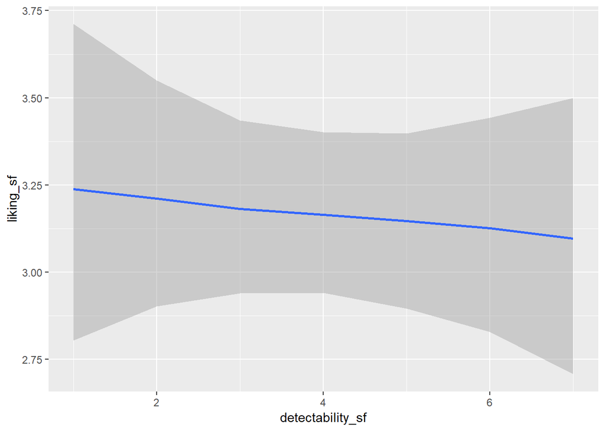

```r
marginal_effects(brm_sf_cumulative)
```

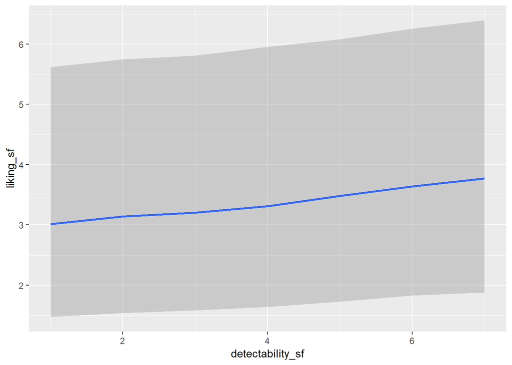

```r
marginal_effects(brm_sf_mixed)
```

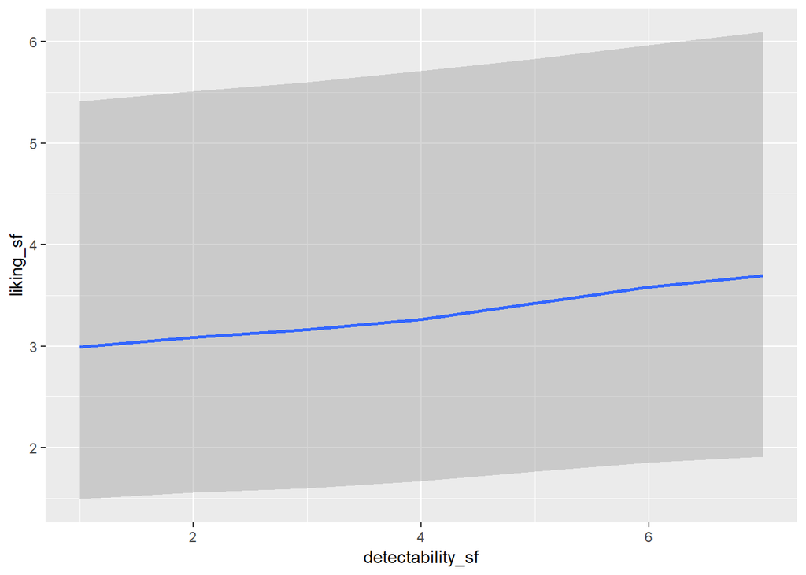

```r
marginal_effects(brm_sf_mixed2)
```